# Data analysis_no_appointment_revised

### The dataset used for this project is about information from 100k *medical appointments* in **Brazil** that foccuses on whether or not patients will show up for their scheduled appointment. Following are the questions i would be analysing for this project:

**Q.1. What percentage of *males and females* didn't show up for the appointment?** Result for Q1

**Q.2. What percentage of different *age groups* didn't show up for the appointment and which group missed the appointment most?** Result for Q2

**Q.3. Which *handicap level* had missed the appointment most? what percentage of different levels didn't show up for the appointment?** Result for Q3

**Q.4. What percentage of patients who receive *scholarship* and those who don't varied in showing up on their scheduled appointment date and which group missed the appointment most?** Result for Q4

**Q.5. what percentage of patients with zero, one, two or all three *conditions*, *Alcholism*, *Hypertension*, and *Diabetes* missed their appointment?** Result for Q5

**Q.6.Does sending *sms* affect the probabilty of patients showing up for the appointment?** Result for Q6

**Q.7 Which *neighbourhood* hospital had the maximum missed appointments?** Result for Q7

**Q.8.Does the difference in number of days between *scheduled date and appointment date* affect the number of missed appointments?** Result for Q8

**Q.9.Does the percentage of missed appointments vary over time?** Result for Q9

```python
import numpy as np
import pandas as pd
import warnings
import datetime as dt
import matplotlib.pyplot as plt
import seaborn as sns
%pylab inline
warnings.filterwarnings('ignore')
```

```python
no_show_appointment=pd.read_csv('noshowappointments-kagglev2-may-2016.csv')
no_show_appointment=no_show_appointment.drop([99832,71533, 27033, 55226, 64175, 72362])
print (no_show_appointment['Age'])
```

```
0         62
1         56
2         62
3          8
4         56
5         76
6         23
7         39
8         21
9         19
10        30
11        29
12        22
13        28
14        54
```

[output cut: 47 more lines]

### Removed records for erroneous values found in age and days_bet_app_and_schdate column from the dataset.

```python
print (len(no_show_appointment['PatientId'].unique()))
```

```
62298
```

```python
print (len(no_show_appointment['AppointmentID'].unique()))
```

```
110521
```

## Q.1. What percentage of *males and females* didn't show up for the appointment?

```python
male_and_female=no_show_appointment.groupby(['No-show','Gender']).size()
male_and_female
```

```
No-show  Gender
No       F         57245
         M         30962
Yes      F         14591
         M          7723
dtype: int64
```

```python
grouped_data=no_show_appointment.groupby('No-show')
grouped_data_missed_appointment=grouped_data.get_group('Yes')
grouped_data_missed_appointment.head()
```

|  | PatientId | AppointmentID | Gender | ScheduledDay | AppointmentDay | Age | Neighbourhood | Scholarship | Hipertension | Diabetes | Alcoholism | Handcap | SMS_received | No-show |
| --- | --- | --- | --- | --- | --- | --- | --- | --- | --- | --- | --- | --- | --- | --- |
| 6 | 7.336882e+14 | 5630279 | F | 2016-04-27T15:05:12Z | 2016-04-29T00:00:00Z | 23 | GOIABEIRAS | 0 | 0 | 0 | 0 | 0 | 0 | Yes |
| 7 | 3.449833e+12 | 5630575 | F | 2016-04-27T15:39:58Z | 2016-04-29T00:00:00Z | 39 | GOIABEIRAS | 0 | 0 | 0 | 0 | 0 | 0 | Yes |
| 11 | 7.542951e+12 | 5620163 | M | 2016-04-26T08:44:12Z | 2016-04-29T00:00:00Z | 29 | NOVA PALESTINA | 0 | 0 | 0 | 0 | 0 | 1 | Yes |
| 17 | 1.479497e+13 | 5633460 | F | 2016-04-28T09:28:57Z | 2016-04-29T00:00:00Z | 40 | CONQUISTA | 1 | 0 | 0 | 0 | 0 | 0 | Yes |
| 20 | 6.222575e+14 | 5626083 | F | 2016-04-27T07:51:14Z | 2016-04-29T00:00:00Z | 30 | NOVA PALESTINA | 0 | 0 | 0 | 0 | 0 | 0 | Yes |

```python
male_and_female_grouped=no_show_appointment.groupby(['Gender']).size()
male_and_female_grouped
```

```
Gender
F    71836
M    38685
dtype: int64
```

```python
grouped_data_missed_appointment_gender=grouped_data_missed_appointment.groupby(['No-show','Gender']).size()
grouped_data_missed_appointment_gender
```

```
No-show  Gender
Yes      F         14591
         M          7723
dtype: int64
```

```python
'''This function takes in total number of entries for a variable and number of entries for that variable present
in either missed appointments groupset or showed up appoinments groupset, and return the percentage of appointments for that variable in either groupset.'''

def percentage_per_group(xs,x):
    percentage_of_appointments=(xs/x)*100
    return percentage_of_appointments
percentage_per_group(20,200)
perc_gender_missed_appointment=percentage_per_group(grouped_data_missed_appointment_gender,male_and_female_grouped)
perc_gender_missed_appointment
```

```
No-show  Gender
Yes      F         20.311543
         M         19.963810
dtype: float64
```

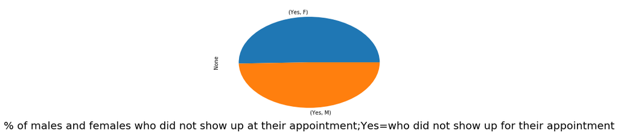

```python
perc_gender_missed_appointment.plot(kind='pie')
matplotlib.rcParams['figure.figsize'] = [15,20]
plt.xlabel('% of males and females who did not show up at their appointment;Yes=who did not show up for their appointment',size=20)
matplotlib.rc('xtick', labelsize=10)
matplotlib.rc('ytick', labelsize=20)
```

### *Result*: No signicant difference was found between the number of males and females who didn't show up for the appointment.

## Q.2. What percentage of different *age-groups* didn't show up for the appointment and which group missed the appointment most?

```python
''' This function takes in a column of dataframe and convert each element of the column into an age-group.'''

def age_group(x):
    if x<=19:
        return '0-19'
    elif x>=20 and x<=40:
        return '20-40'
    elif x>=41 and x<=60:
        return '41-60'
    elif x>=61 and x<=80:
        return '61-80'
    else:
        return 'Above 80'
age_group(56)
print (no_show_appointment)
Age_group=no_show_appointment['Age'].apply(age_group)
no_show_appointment['Age_group']=Age_group
grouped_data_missed_appointment['Age_group']=Age_group
(no_show_appointment).head(3)
```

```
           PatientId  AppointmentID Gender          ScheduledDay  \
0       2.987250e+13        5642903      F  2016-04-29T18:38:08Z
1       5.589978e+14        5642503      M  2016-04-29T16:08:27Z
2       4.262962e+12        5642549      F  2016-04-29T16:19:04Z
3       8.679512e+11        5642828      F  2016-04-29T17:29:31Z
4       8.841186e+12        5642494      F  2016-04-29T16:07:23Z
5       9.598513e+13        5626772      F  2016-04-27T08:36:51Z
6       7.336882e+14        5630279      F  2016-04-27T15:05:12Z
7       3.449833e+12        5630575      F  2016-04-27T15:39:58Z
8       5.639473e+13        5638447      F  2016-04-29T08:02:16Z
9       7.812456e+13        5629123      F  2016-04-27T12:48:25Z
10      7.345362e+14        5630213      F  2016-04-27T14:58:11Z
11      7.542951e+12        5620163      M  2016-04-26T08:44:12Z
12      5.666548e+14        5634718      F  2016-04-28T11:33:51Z
13      9.113946e+14        5636249      M  2016-04-28T14:52:07Z
```

[output cut: 175 more lines]

|  | PatientId | AppointmentID | Gender | ScheduledDay | AppointmentDay | Age | Neighbourhood | Scholarship | Hipertension | Diabetes | Alcoholism | Handcap | SMS_received | No-show | Age_group |
| --- | --- | --- | --- | --- | --- | --- | --- | --- | --- | --- | --- | --- | --- | --- | --- |
| 0 | 2.987250e+13 | 5642903 | F | 2016-04-29T18:38:08Z | 2016-04-29T00:00:00Z | 62 | JARDIM DA PENHA | 0 | 1 | 0 | 0 | 0 | 0 | No | 61-80 |
| 1 | 5.589978e+14 | 5642503 | M | 2016-04-29T16:08:27Z | 2016-04-29T00:00:00Z | 56 | JARDIM DA PENHA | 0 | 0 | 0 | 0 | 0 | 0 | No | 41-60 |
| 2 | 4.262962e+12 | 5642549 | F | 2016-04-29T16:19:04Z | 2016-04-29T00:00:00Z | 62 | MATA DA PRAIA | 0 | 0 | 0 | 0 | 0 | 0 | No | 61-80 |

```python
grouped_age_group=no_show_appointment.groupby(['Age_group']).size()
grouped_data_missed_appointment_age_group=grouped_data_missed_appointment.groupby(['No-show','Age_group']).size()
perc_age_group_missed_appointment=percentage_per_group(grouped_data_missed_appointment_age_group,grouped_age_group)



print (grouped_age_group)
print (grouped_data_missed_appointment_age_group)
print (perc_age_group_missed_appointment)
```

```
Age_group
0-19        30409
20-40       30270
41-60       30081
61-80       16910
Above 80     2851
dtype: int64
No-show  Age_group
Yes      0-19         6739
         20-40        6979
         41-60        5591
         61-80        2537
         Above 80      468
dtype: int64
No-show  Age_group
Yes      0-19         22.161202
         20-40        23.055831
         41-60        18.586483
         61-80        15.002957
         Above 80     16.415293
dtype: float64
```

```python
age_group_missed_most=perc_age_group_missed_appointment.argmax()
print (age_group_missed_most)
```

```
('Yes', '20-40')
```

```
Text(0,0.5,'% of missed appointments')
```

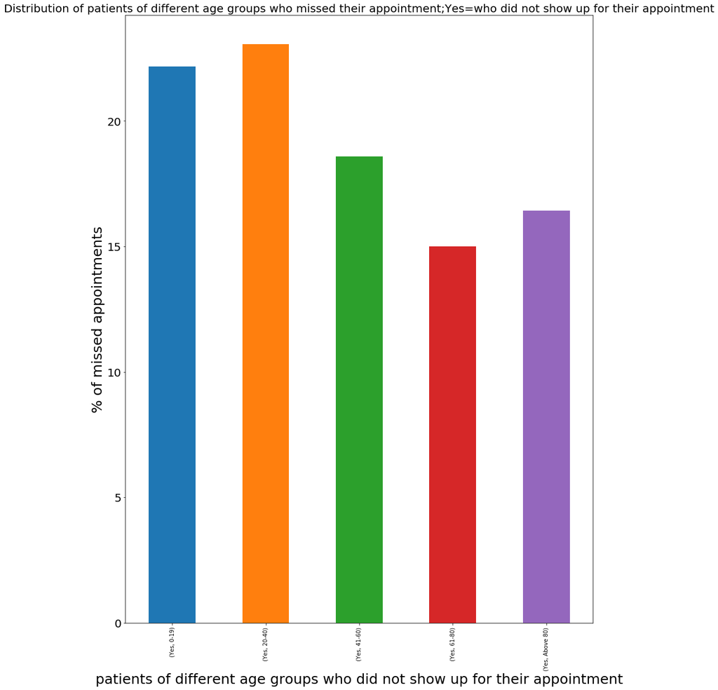

```python
perc_age_group_missed_appointment.plot(kind='bar')
matplotlib.rcParams['figure.figsize'] = [25, 10]
plt.title('Distribution of patients of different age groups who missed their appointment;Yes=who did not show up for their appointment',size=20)
plt.xlabel('patients of different age groups who did not show up for their appointment',size=25)
plt.ylabel('% of missed appointments',size=25)
```

### *Result*: Patients in the age group (20-40) had relatively higher number of missed appointments.

## Q.3. Which *handicap level* had missed the appointment most? what percentage of different levels didn't show up for the appointment?

```python
grouped_Handicap=no_show_appointment.groupby(['Handcap']).size()
grouped_data_no_show_Handicap=no_show_appointment.groupby(['No-show','Handcap']).size()
grouped_data_missed_appointment_Handicap=grouped_data_missed_appointment.groupby(['No-show','Handcap']).size()
perc_handicap_missed_appointment=percentage_per_group(grouped_data_missed_appointment_Handicap,grouped_Handicap)


print (grouped_Handicap)
print (grouped_data_no_show_Handicap)
print (grouped_data_missed_appointment_Handicap)
print (perc_handicap_missed_appointment)
```

```
Handcap
0    108282
1      2040
2       183
3        13
4         3
dtype: int64
No-show  Handcap
No       0          86373
         1           1676
         2            146
         3             10
         4              2
Yes      0          21909
         1            364
         2             37
         3              3
         4              1
dtype: int64
No-show  Handcap
Yes      0          21909
         1            364
         2             37
         3              3
         4              1
dtype: int64
No-show  Handcap
Yes      0          20.233280
         1          17.843137
         2          20.218579
         3          23.076923
         4          33.333333
dtype: float64
```

```python
Handicap_level_missed_most=perc_handicap_missed_appointment.argmax()
Handicap_level_missed_most
```

```
('Yes', 4)
```

```
Text(0,0.5,'% of missed appointments')
```

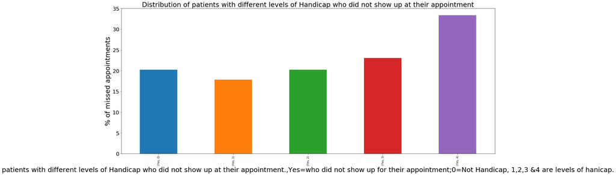

```python
perc_handicap_missed_appointment.plot(kind='bar')
matplotlib.rcParams['figure.figsize'] = [30, 10]
plt.xlabel('patients with different levels of Handicap who did not show up at their appointment.,Yes=who did not show up for their appointment;0=Not Handicap, 1,2,3 &4 are levels of hanicap.',size=25)
plt.title('Distribution of patients with different levels of Handicap who did not show up at their appointment',size=25)
plt.ylabel('% of missed appointments',size=25)
```

### *Result*: Patients with handicap level 4 had the highest number of missed appointments while patients with handicap level 1 had the lowest.

## Q.4. What percentage of patients who receive *scholarship* and those who don't varied in showing up on their scheduled appointment date and which group missed the appointment most?

```python
grouped_Scholarship=no_show_appointment.groupby(['Scholarship']).size()
grouped_data_no_show_Scholarship=no_show_appointment.groupby(['No-show','Scholarship']).size()
grouped_data_missed_appointment_Scholarship=grouped_data_missed_appointment.groupby(['No-show','Scholarship']).size()
perc_scholarship_missed_appointment=percentage_per_group(grouped_data_missed_appointment_Scholarship,grouped_Scholarship)

print (grouped_Scholarship)
print (grouped_data_no_show_Scholarship)
print (grouped_data_missed_appointment_Scholarship)
print (perc_scholarship_missed_appointment)
```

```
Scholarship
0    99660
1    10861
dtype: int64
No-show  Scholarship
No       0              79924
         1               8283
Yes      0              19736
         1               2578
dtype: int64
No-show  Scholarship
Yes      0              19736
         1               2578
dtype: int64
No-show  Scholarship
Yes      0              19.803331
         1              23.736304
dtype: float64
```

```python
scholarship_missed_app_most=perc_scholarship_missed_appointment.argmax()
print (scholarship_missed_app_most)
```

```
('Yes', 1)
```

```
Text(0.5,0,'Percentage of missed appointments for patients who receives scholarship Vs those who do not;Yes=who did not show up for their appointment;0=who do not get scolarship,1=who gets scolarship')
```

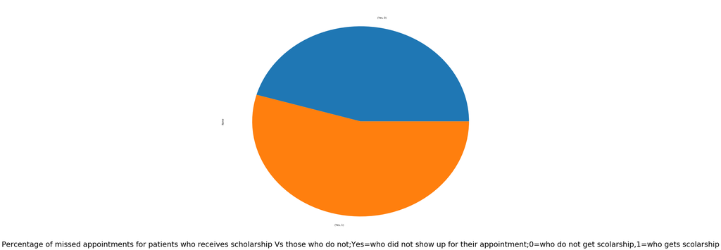

```python
matplotlib.rcParams['figure.figsize'] = [20, 18]
perc_scholarship_missed_appointment.plot(kind='pie')
plt.xlabel('Percentage of missed appointments for patients who receives scholarship Vs those who do not;Yes=who did not show up for their appointment;0=who do not get scolarship,1=who gets scolarship',size=30)
```

### *Result*: Patients who recieve scholarship had more missed appointments as compared to people who don't receive.

## Q.5. what percentage of patients with zero, one, two or all three *conditions*, *Alcholism*, *Hypertension*, and *Diabetes* missed their appointment?

```python
sum_of_conditions=no_show_appointment[['Hipertension','Diabetes','Alcoholism']].sum(axis=1)
no_show_appointment['patient_total_conditions']=sum_of_conditions
grouped_data_missed_appointment['patient_total_conditions']=sum_of_conditions
no_show_appointment.head()
```

|  | PatientId | AppointmentID | Gender | ScheduledDay | AppointmentDay | Age | Neighbourhood | Scholarship | Hipertension | Diabetes | Alcoholism | Handcap | SMS_received | No-show | Age_group | patient_total_conditions |
| --- | --- | --- | --- | --- | --- | --- | --- | --- | --- | --- | --- | --- | --- | --- | --- | --- |
| 0 | 2.987250e+13 | 5642903 | F | 2016-04-29T18:38:08Z | 2016-04-29T00:00:00Z | 62 | JARDIM DA PENHA | 0 | 1 | 0 | 0 | 0 | 0 | No | 61-80 | 1 |
| 1 | 5.589978e+14 | 5642503 | M | 2016-04-29T16:08:27Z | 2016-04-29T00:00:00Z | 56 | JARDIM DA PENHA | 0 | 0 | 0 | 0 | 0 | 0 | No | 41-60 | 0 |
| 2 | 4.262962e+12 | 5642549 | F | 2016-04-29T16:19:04Z | 2016-04-29T00:00:00Z | 62 | MATA DA PRAIA | 0 | 0 | 0 | 0 | 0 | 0 | No | 61-80 | 0 |
| 3 | 8.679512e+11 | 5642828 | F | 2016-04-29T17:29:31Z | 2016-04-29T00:00:00Z | 8 | PONTAL DE CAMBURI | 0 | 0 | 0 | 0 | 0 | 0 | No | 0-19 | 0 |
| 4 | 8.841186e+12 | 5642494 | F | 2016-04-29T16:07:23Z | 2016-04-29T00:00:00Z | 56 | JARDIM DA PENHA | 0 | 1 | 1 | 0 | 0 | 0 | No | 41-60 | 2 |

```python
grouped_data_missed_appointment.head()
```

|  | PatientId | AppointmentID | Gender | ScheduledDay | AppointmentDay | Age | Neighbourhood | Scholarship | Hipertension | Diabetes | Alcoholism | Handcap | SMS_received | No-show | Age_group | patient_total_conditions |
| --- | --- | --- | --- | --- | --- | --- | --- | --- | --- | --- | --- | --- | --- | --- | --- | --- |
| 6 | 7.336882e+14 | 5630279 | F | 2016-04-27T15:05:12Z | 2016-04-29T00:00:00Z | 23 | GOIABEIRAS | 0 | 0 | 0 | 0 | 0 | 0 | Yes | 20-40 | 0 |
| 7 | 3.449833e+12 | 5630575 | F | 2016-04-27T15:39:58Z | 2016-04-29T00:00:00Z | 39 | GOIABEIRAS | 0 | 0 | 0 | 0 | 0 | 0 | Yes | 20-40 | 0 |
| 11 | 7.542951e+12 | 5620163 | M | 2016-04-26T08:44:12Z | 2016-04-29T00:00:00Z | 29 | NOVA PALESTINA | 0 | 0 | 0 | 0 | 0 | 1 | Yes | 20-40 | 0 |
| 17 | 1.479497e+13 | 5633460 | F | 2016-04-28T09:28:57Z | 2016-04-29T00:00:00Z | 40 | CONQUISTA | 1 | 0 | 0 | 0 | 0 | 0 | Yes | 20-40 | 0 |
| 20 | 6.222575e+14 | 5626083 | F | 2016-04-27T07:51:14Z | 2016-04-29T00:00:00Z | 30 | NOVA PALESTINA | 0 | 0 | 0 | 0 | 0 | 0 | Yes | 20-40 | 0 |

```python
grouped_total_conditions=no_show_appointment.groupby(['patient_total_conditions']).size()
grouped_data_no_show_conditions=no_show_appointment.groupby(['No-show','patient_total_conditions']).size()
grouped_data_missed_appointment_conditions=grouped_data_missed_appointment.groupby(['No-show','patient_total_conditions']).size()
percentage_conditions_missed_appointments=percentage_per_group(grouped_data_missed_appointment_conditions,grouped_total_conditions)




print (grouped_total_conditions)
print (grouped_data_no_show_conditions)
print (grouped_data_missed_appointment_conditions)
print (percentage_conditions_missed_appointments)
```

```
patient_total_conditions
0    85306
1    17582
2     7377
3      256
dtype: int64
No-show  patient_total_conditions
No       0                           67473
         1                           14453
         2                            6071
         3                             210
Yes      0                           17833
         1                            3129
         2                            1306
         3                              46
dtype: int64
No-show  patient_total_conditions
Yes      0                           17833
         1                            3129
         2                            1306
         3                              46
dtype: int64
No-show  patient_total_conditions
Yes      0                           20.904743
         1                           17.796610
         2                           17.703674
         3                           17.968750
dtype: float64
```

```python
condition_missed_app_most=percentage_conditions_missed_appointments.argmax()
print (condition_missed_app_most)
```

```
('Yes', 0)
```

```
Text(0,0.5,'% of missed appointments')
```

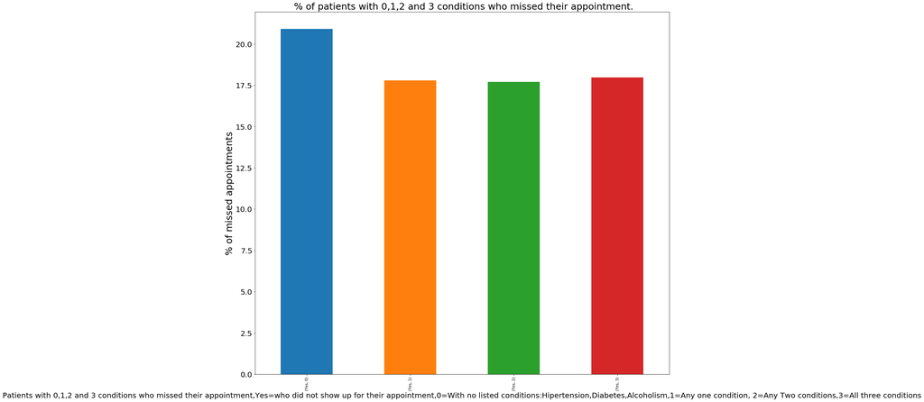

```python
percentage_conditions_missed_appointments.plot(kind='bar')
matplotlib.rcParams['figure.figsize'] = [40, 10]
plt.title(' % of patients with 0,1,2 and 3 conditions who missed their appointment.',size=25)
plt.xlabel('Patients with 0,1,2 and 3 conditions who missed their appointment,Yes=who did not show up for their appointment,0=With no listed conditions:Hipertension,Diabetes,Alcoholism,1=Any one condition, 2=Any Two conditions,3=All three conditions',size=20)
plt.ylabel('% of missed appointments',size=25)
```

### *Result*: Patients with no conditions listed (Alcholism, Diabetes and Hypertension) had the relatively higher number of missed appointments as compared to people with 1, 2, or all 3 conditions. While the number of people with 1, 2, or all 3 conditions had similar number of missed appointment.

## Q.6. Does sending *sms* affects the probabilty of patient showing up for the appointment?

```python
grouped_sms=no_show_appointment.groupby(['SMS_received']).size()
grouped_data_no_show_sms=no_show_appointment.groupby(['No-show','SMS_received']).size()
grouped_data_missed_appointments_sms=grouped_data_missed_appointment.groupby(['No-show','SMS_received']).size()
percentage_missed_appointments_sms=percentage_per_group(grouped_data_missed_appointments_sms,grouped_sms)
sms_missed_app_most=percentage_missed_appointments_sms.argmax()
percentage_sms_fulldata=percentage_per_group(grouped_data_no_show_sms,grouped_sms)


print (grouped_sms)
print (grouped_data_no_show_sms)
print (grouped_data_missed_appointments_sms)
print (percentage_missed_appointments_sms)
print (sms_missed_app_most)
print(percentage_sms_fulldata)
```

```
SMS_received
0    75039
1    35482
dtype: int64
No-show  SMS_received
No       0               62509
         1               25698
Yes      0               12530
         1                9784
dtype: int64
No-show  SMS_received
Yes      0               12530
         1                9784
dtype: int64
No-show  SMS_received
Yes      0               16.697984
         1               27.574545
dtype: float64
('Yes', 1)
No-show  SMS_received
No       0               83.302016
         1               72.425455
Yes      0               16.697984
         1               27.574545
dtype: float64
```

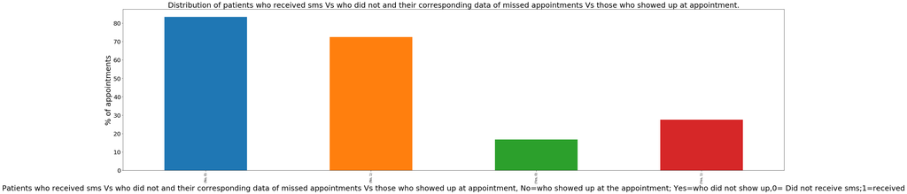

```python
percentage_sms_fulldata.plot(kind='bar')
matplotlib.rcParams['figure.figsize'] = [30, 15]
plt.title('Distribution of patients who received sms Vs who did not and their corresponding data of missed appointments Vs those who showed up at appointment.',size=25)
plt.xlabel('Patients who received sms Vs who did not and their corresponding data of missed appointments Vs those who showed up at appointment, No=who showed up at the appointment; Yes=who did not show up,0= Did not receive sms;1=received',size=25)
plt.ylabel('% of appointments',size=25)
matplotlib.rc('xtick', labelsize=25)
matplotlib.rc('ytick', labelsize=7)
```

### *Result*: The analysis showed that receiving sms doesn't seem to be positively impacting the attendance. In fact, the patients who did not recieve SMS seem to show up more for appointments.

## Q.7 Which *neighbourhood* hospital had the maximum missed appointments?

```python
grouped_neighbourhood=no_show_appointment.groupby(['Neighbourhood']).size()
grouped_data_no_show_Neighbourhood=no_show_appointment.groupby(['No-show','Neighbourhood']).size()
grouped_data_missed_appointment_Neighbourhood=grouped_data_missed_appointment.groupby(['No-show','Neighbourhood']).size()
percentage_missed_appointment_Neighbourhood=percentage_per_group(grouped_data_missed_appointment_Neighbourhood,grouped_neighbourhood)
neighbourhood_missed_app_most=percentage_missed_appointment_Neighbourhood.argmax()



print (grouped_neighbourhood)
print (grouped_data_no_show_Neighbourhood)
print (grouped_data_missed_appointment_Neighbourhood)
print (percentage_missed_appointment_Neighbourhood)
print (neighbourhood_missed_app_most)
```

```
Neighbourhood
AEROPORTO                 8
ANDORINHAS             2262
ANTÔNIO HONÓRIO         271
ARIOVALDO FAVALESSA     282
BARRO VERMELHO          423
BELA VISTA             1907
BENTO FERREIRA          858
BOA VISTA               312
BONFIM                 2773
CARATOÍRA              2565
CENTRO                 3334
COMDUSA                 310
CONQUISTA               849
CONSOLAÇÃO             1375
CRUZAMENTO             1398
DA PENHA               2217
DE LOURDES              305
DO CABRAL               560
DO MOSCOSO              413
DO QUADRO               849
ENSEADA DO SUÁ          235
ESTRELINHA              538
FONTE GRANDE            682
FORTE SÃO JOÃO         1889
FRADINHOS               258
GOIABEIRAS              700
GRANDE VITÓRIA         1071
GURIGICA               2018
HORTO                   175
ILHA DAS CAIEIRAS      1071
                       ...
PARQUE INDUSTRIAL         1
PARQUE MOSCOSO          802
PIEDADE                 452
PONTAL DE CAMBURI        69
PRAIA DO CANTO         1035
PRAIA DO SUÁ           1288
REDENÇÃO               1553
REPÚBLICA               835
```

[output cut: 198 more lines]

```
         SANTO ANDRÉ            19.758849
         SANTO ANTÔNIO          17.565598
         SANTOS DUMONT          28.918495
         SANTOS REIS            20.475320
         SEGURANÇA DO LAR       19.310345
         SOLON BORGES           14.712154
         SÃO BENEDITO           19.944406
         SÃO CRISTÓVÃO          19.771242
         SÃO JOSÉ               21.648963
         SÃO PEDRO              21.037582
         TABUAZEIRO             18.268924
         UNIVERSITÁRIO          21.052632
         VILA RUBIM             16.568743
Length: 80, dtype: float64
('Yes', 'ILHAS OCEÂNICAS DE TRINDADE')
```

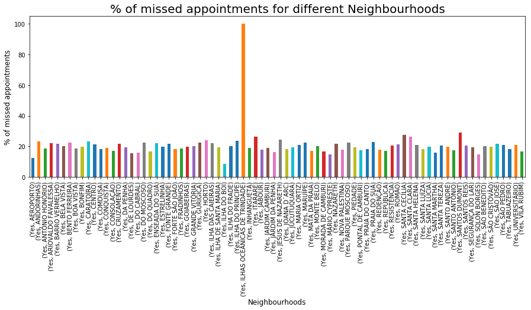

```python
matplotlib.rcParams['figure.figsize'] = [15, 5]
percentage_missed_appointment_Neighbourhood.plot(kind='bar')
plt.title('% of missed appointments for different Neighbourhoods',size=20)
plt.xlabel('Neighbourhoods',size=12)
plt.ylabel('% of missed appointments',size=12)
matplotlib.rc('xtick', labelsize=10)
matplotlib.rc('ytick', labelsize=10)
```

### *Result*: There is no substantial difference based on neighbourhood. The spike in the plot is due to too small data set for the corresponding neighbourhood that skewed the result.

## Q.8.Does the difference in number of days between *scheduled date and appointment date* affect the number of missed appointments?

```python
no_show_appointment['ScheduledDate'] = no_show_appointment['ScheduledDay'].str[:10]
no_show_appointment['AppointmentDate'] = no_show_appointment['AppointmentDay'].str[:10]
no_show_appointment['ScheduledDate'] = pd.to_datetime(no_show_appointment['ScheduledDate'])
no_show_appointment['AppointmentDate'] = pd.to_datetime(no_show_appointment['AppointmentDate'])
no_show_appointment['days_bet_app_and_schdate']=(no_show_appointment['AppointmentDate'])-(no_show_appointment['ScheduledDate'])
grouped_data_missed_appointment['ScheduledDate'] = no_show_appointment['ScheduledDay'].str[:10]
grouped_data_missed_appointment['AppointmentDate'] = no_show_appointment['AppointmentDay'].str[:10]
grouped_data_missed_appointment['ScheduledDate'] = pd.to_datetime(no_show_appointment['ScheduledDate'])
grouped_data_missed_appointment['AppointmentDate'] = pd.to_datetime(no_show_appointment['AppointmentDate'])
grouped_data_missed_appointment['days_bet_app_and_schdate']=(no_show_appointment['AppointmentDate'])-(no_show_appointment['ScheduledDate'])
no_show_appointment.head(10)
```

|  | PatientId | AppointmentID | Gender | ScheduledDay | AppointmentDay | Age | Neighbourhood | Scholarship | Hipertension | Diabetes | Alcoholism | Handcap | SMS_received | No-show | Age_group | patient_total_conditions | ScheduledDate | AppointmentDate | days_bet_app_and_schdate |
| --- | --- | --- | --- | --- | --- | --- | --- | --- | --- | --- | --- | --- | --- | --- | --- | --- | --- | --- | --- |
| 0 | 2.987250e+13 | 5642903 | F | 2016-04-29T18:38:08Z | 2016-04-29T00:00:00Z | 62 | JARDIM DA PENHA | 0 | 1 | 0 | 0 | 0 | 0 | No | 61-80 | 1 | 2016-04-29 | 2016-04-29 | 0 days |
| 1 | 5.589978e+14 | 5642503 | M | 2016-04-29T16:08:27Z | 2016-04-29T00:00:00Z | 56 | JARDIM DA PENHA | 0 | 0 | 0 | 0 | 0 | 0 | No | 41-60 | 0 | 2016-04-29 | 2016-04-29 | 0 days |
| 2 | 4.262962e+12 | 5642549 | F | 2016-04-29T16:19:04Z | 2016-04-29T00:00:00Z | 62 | MATA DA PRAIA | 0 | 0 | 0 | 0 | 0 | 0 | No | 61-80 | 0 | 2016-04-29 | 2016-04-29 | 0 days |
| 3 | 8.679512e+11 | 5642828 | F | 2016-04-29T17:29:31Z | 2016-04-29T00:00:00Z | 8 | PONTAL DE CAMBURI | 0 | 0 | 0 | 0 | 0 | 0 | No | 0-19 | 0 | 2016-04-29 | 2016-04-29 | 0 days |
| 4 | 8.841186e+12 | 5642494 | F | 2016-04-29T16:07:23Z | 2016-04-29T00:00:00Z | 56 | JARDIM DA PENHA | 0 | 1 | 1 | 0 | 0 | 0 | No | 41-60 | 2 | 2016-04-29 | 2016-04-29 | 0 days |
| 5 | 9.598513e+13 | 5626772 | F | 2016-04-27T08:36:51Z | 2016-04-29T00:00:00Z | 76 | REPÚBLICA | 0 | 1 | 0 | 0 | 0 | 0 | No | 61-80 | 1 | 2016-04-27 | 2016-04-29 | 2 days |
| 6 | 7.336882e+14 | 5630279 | F | 2016-04-27T15:05:12Z | 2016-04-29T00:00:00Z | 23 | GOIABEIRAS | 0 | 0 | 0 | 0 | 0 | 0 | Yes | 20-40 | 0 | 2016-04-27 | 2016-04-29 | 2 days |
| 7 | 3.449833e+12 | 5630575 | F | 2016-04-27T15:39:58Z | 2016-04-29T00:00:00Z | 39 | GOIABEIRAS | 0 | 0 | 0 | 0 | 0 | 0 | Yes | 20-40 | 0 | 2016-04-27 | 2016-04-29 | 2 days |
| 8 | 5.639473e+13 | 5638447 | F | 2016-04-29T08:02:16Z | 2016-04-29T00:00:00Z | 21 | ANDORINHAS | 0 | 0 | 0 | 0 | 0 | 0 | No | 20-40 | 0 | 2016-04-29 | 2016-04-29 | 0 days |
| 9 | 7.812456e+13 | 5629123 | F | 2016-04-27T12:48:25Z | 2016-04-29T00:00:00Z | 19 | CONQUISTA | 0 | 0 | 0 | 0 | 0 | 0 | No | 0-19 | 0 | 2016-04-27 | 2016-04-29 | 2 days |

```python
#no_show_appointment.groupby(['days_bet_app_and_schdate']).groups
#no_show_appointment.iloc[71533]
no_show_appointment.groupby(['days_bet_app_and_schdate']).groups
```

[output not shown]

[output cut: 598 more lines]

[output not shown]

```python
grouped_total_daysdiff=no_show_appointment.groupby(['days_bet_app_and_schdate']).size()
grouped_data_daysdiff=no_show_appointment.groupby(['No-show','days_bet_app_and_schdate']).size()
grouped_data_missed_appointment_daysdiff=grouped_data_missed_appointment.groupby(['No-show','days_bet_app_and_schdate']).size()
percentage_missed_appointment_daysdiff=percentage_per_group(grouped_data_missed_appointment_daysdiff,grouped_total_daysdiff)



print (grouped_total_daysdiff)
print (grouped_data_daysdiff)
print (grouped_data_missed_appointment_daysdiff)
print (percentage_missed_appointment_daysdiff)
```

```
days_bet_app_and_schdate
0 days      38562
1 days       5213
2 days       6725
3 days       2737
4 days       5290
5 days       3277
6 days       4037
7 days       4906
8 days       2332
9 days       1605
10 days      1391
11 days       987
12 days      1115
13 days      1682
```

[output cut: 237 more lines]

```python
daysdiff_missed_app_min=percentage_missed_appointment_daysdiff.argmin()
print (daysdiff_missed_app_min)
```

```
('Yes', Timedelta('0 days 00:00:00'))
```

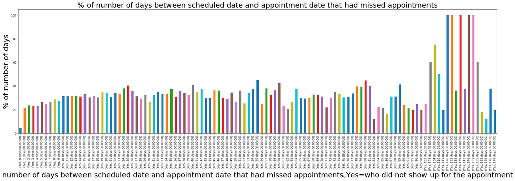

```python
matplotlib.rcParams['figure.figsize'] = [30, 8]
xlim(0, 179)
percentage_missed_appointment_daysdiff.plot(kind='bar')
plt.title('% of number of days between scheduled date and appointment date that had missed appointments',size=25)
plt.xlabel('number of days between scheduled date and appointment date that had missed appointments,Yes=who did not show up for the appointment', size=25)
plt.ylabel('% of number of days',size=25)
matplotlib.rc('xtick', labelsize=20)
matplotlib.rc('ytick', labelsize=30)
```